# Malicious domain names detection with H2O

31-3-2022

## .Data Science

**Data science** is an interdisciplinary field that uses scientific methods, processes, algorithms and systems to extract knowledge and insights from noisy, structured and unstructured data. Source: [wikipedia](https://en.wikipedia.org/wiki/Data_science)

## .Data Science Syllabus

- Introduction
- Data collection and scraping
- Jupyter Notebook lab
- Relational data
- Visualization and data exploration
- Vectors, matrices, and linear algebra
- Graph and network processing
- Free text and natural language processing
- Introduction to machine learning
- Linear classification
- Nonlinear modeling, cross-validation

## .Data Science Syllabus - cont.

- Basics of probability
- Maximum likelihood estimation, naïve Bayes
- Hypothesis testing and experimental design
- Unsupervised learning
- Recommender systems
- Decision trees, interpretable models
- Deep learning
- Big data and MapReduce methods
- Debugging data science
- A data science walkthrough
- The future of data science and Q&A

**Source:** [Carnegie Mellon University](https://www.datasciencecourse.org/lectures/)

## .Data Science In The Wild

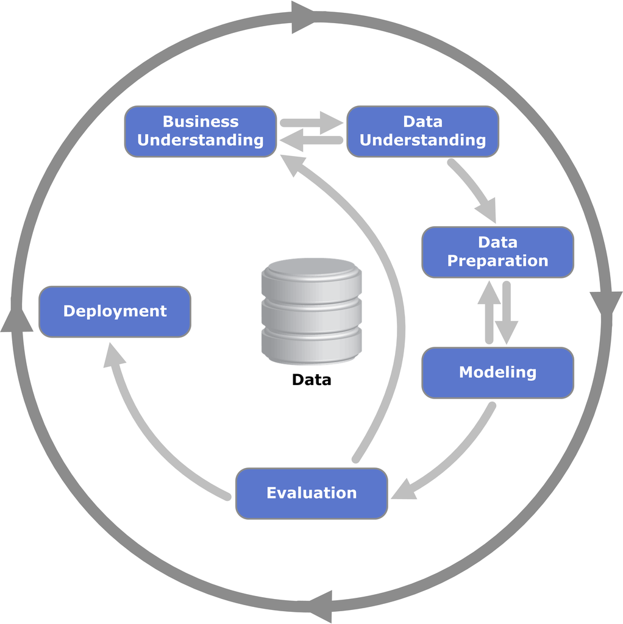

Cross-industry standard process for data mining. Source: [wikipedia](https://en.wikipedia.org/wiki/Cross-industry_standard_process_for_data_mining)

## .Hands on Data Science - ‘Iris’ Data Set

```r
# Loads the packages that we need.
library(tidyverse) # metapackage of all tidyverse packages
library(tidymodels) # metapackage of all tidymodels packages

# Loads the iris data that we will use.
data(iris)
```

## .Hands on Data Science - ‘Iris’ Data Set

```r
# check the header
iris %>% head()
```

```
##   Sepal.Length Sepal.Width Petal.Length Petal.Width Species
## 1          5.1         3.5          1.4         0.2  setosa
## 2          4.9         3.0          1.4         0.2  setosa
## 3          4.7         3.2          1.3         0.2  setosa
## 4          4.6         3.1          1.5         0.2  setosa
## 5          5.0         3.6          1.4         0.2  setosa
## 6          5.4         3.9          1.7         0.4  setosa
```

## .Hands on Data Science - ‘Iris’ Data Set

```r
# check the target variable
iris %>% select(Species) %>% table()
```

```
## .
##     setosa versicolor  virginica
##         50         50         50
```

## .Hands on Data Science - ‘Iris’ Data Set

```r
# check the predictor variables
my_plot <- iris %>%
  ggplot() +
  aes(x=Sepal.Width, fill=Species) +
  geom_density(stat="density", alpha=I(0.2)) +
  xlab("Sepal Width") +
  ylab("Density") +
  ggtitle("Density Curve of Sepal Width")
```

## .Hands on Data Science - ‘Iris’ Data Set

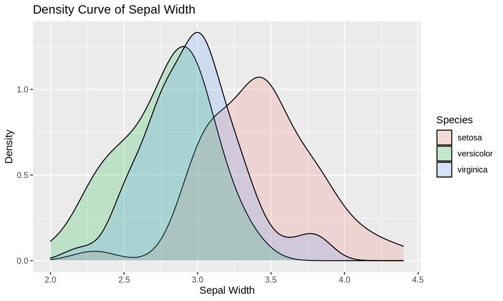

## .Hands on Data Science - ‘Iris’ Data Set

```r
# Sets a random seed. By choosing this seed, our results will
# be reproducible.
set.seed(123)

# This creates an rsplit object. We can use it to break our data
# into a training set a test set.
iris_split <- initial_split(iris, prop = 0.80)
iris_split
```

```
## <Analysis/Assess/Total>
## <120/30/150>
```

## .Hands on Data Science - ‘Iris’ Data Set

```r
# Now we break out data into a training set and a test set.
iris_train <- training(iris_split)
iris_test <- testing(iris_split)

dim(iris_train)
```

```
## [1] 120   5
```

## .Hands on Data Science - ‘Iris’ Data Set

```r
# Define recipe.
iris_recipe <-
    recipe(Species ~ Sepal.Length + Sepal.Width + Petal.Length + Petal.Width,
           data = iris_train)

iris_recipe
```

```
## Recipe
##
## Inputs:
##
##       role #variables
##    outcome          1
##  predictor          4
```

## .Hands on Data Science - ‘Iris’ Data Set

```r
# Preprocessing recipe.
iris_prep <- prep(iris_recipe, training = iris_train)
iris_prep
```

```
## Recipe
##
## Inputs:
##
##       role #variables
##    outcome          1
##  predictor          4
##
## Training data contained 120 data points and no missing data.
```

## .Hands on Data Science - ‘Iris’ Data Set

```r
# Bake preprocessed recipe.
train_ex <- bake(iris_prep, new_data = NULL)
test_ex <- bake(iris_prep, new_data = iris_test)
train_ex %>% head()
```

```
## # A tibble: 6 × 5
##   Sepal.Length Sepal.Width Petal.Length Petal.Width Species
##          <dbl>       <dbl>        <dbl>       <dbl> <fct>
## 1          5           3.5          1.6         0.6 setosa
## 2          7.7         3.8          6.7         2.2 virginica
## 3          5           2            3.5         1   versicolor
## 4          7.2         3            5.8         1.6 virginica
## 5          6.4         3.1          5.5         1.8 virginica
## 6          4.6         3.4          1.4         0.3 setosa
```

## .Hands on Data Science - ‘Iris’ Data Set

```r
# Specify model.
rf_model <-
    rand_forest(trees = 1000, min_n = 5) %>%
    set_engine("ranger") %>%
    set_mode("classification")

translate(rf_model)
```

```
## Random Forest Model Specification (classification)
##
## Main Arguments:
##   trees = 1000
##   min_n = 5
##
## Computational engine: ranger
##
## Model fit template:
## ranger::ranger(x = missing_arg(), y = missing_arg(), case.weights = missing_arg(),
##     num.trees = 1000, min.node.size = min_rows(~5, x), num.threads = 1,
##     verbose = FALSE, seed = sample.int(10^5, 1), probability = TRUE)
```

## .Hands on Data Science - ‘Iris’ Data Set

```r
# Specify workflow.
rf_wflow <-
    workflow() %>%
    add_model(rf_model) %>%
    add_recipe(iris_prep)
```

## .Hands on Data Science - ‘Iris’ Data Set

```r
# Fit the model.
rf_fit <- fit(rf_wflow, iris_train)
rf_fit
```

```
## ══ Workflow [trained] ══════════════════════════════════════════════════════════
## Preprocessor: Recipe
## Model: rand_forest()
##
## ── Preprocessor ────────────────────────────────────────────────────────────────
## 0 Recipe Steps
##
## ── Model ───────────────────────────────────────────────────────────────────────
## Ranger result
##
## Call:
##  ranger::ranger(x = maybe_data_frame(x), y = y, num.trees = ~1000,      min.node.size = min_rows(~5, x), num.threads = 1, verbose = FALSE,      seed = sample.int(10^5, 1), probability = TRUE)
##
## Type:                             Probability estimation
## Number of trees:                  1000
## Sample size:                      120
## Number of independent variables:  4
## Mtry:                             2
## Target node size:                 5
## Variable importance mode:         none
## Splitrule:                        gini
## OOB prediction error (Brier s.):  0.0340403
```

## .Hands on Data Science - ‘Iris’ Data Set

```r
# Evaluate the model with Accuracy and Kappa.
rf_fit %>%
    predict(test_ex) %>%
    bind_cols(test_ex) %>%
    metrics(truth = Species, estimate = .pred_class)
```

```
## # A tibble: 2 × 3
##   .metric  .estimator .estimate
##   <chr>    <chr>          <dbl>
## 1 accuracy multiclass     0.967
## 2 kap      multiclass     0.949
```

Accuracy is the proportion of the data that are predicted correctly.

Kappa is a similar measure to `accuracy` very useful when one or more classes have large frequency distributions

## .Hands on Data Science - ‘Iris’ Data Set

```r
# Evaluate the model with Confusion Matrix.
rf_fit %>%
  predict(test_ex) %>%
  bind_cols(test_ex) %>%
  conf_mat(Species, .pred_class)
```

```
##             Truth
## Prediction   setosa versicolor virginica
##   setosa          8          0         0
##   versicolor      0          9         1
##   virginica       0          0        12
```

## .Hands on Data Science - ‘Iris’ Data Set

Model deployment in `R`:

- Web Service - `plumber`
- Web Application - `shiny`

## .Code Surgery - Malicious Domain Names

[figure not shown]